# VisiDati Testi un Grafiki

Diāna / Rūta

2026-04-27

# Darbam nepieciešamās pakotnes

```r
library(readxl) # Excel failu nolasīšanai
library(tidyverse) # ietver dplyr, ggplot2, stringr un lubridate
library(nnet) # specifiskiem statistiskajiem modeļiem
library(pscl) # papildu statistiskajiem aprēķiniem
```

## Premise

Kas mums ir:

- “ground truth” (MANUAL_MATCH)
- manuālā pārbaude - automātiskā metode (PM_MATCH + validated_fragment (kas apstiprina (1) vai noliedz (0) PM matchus)
- eksperimentālie faktori (mainīgie): threshold (0.1, 0.2, 0.3) un template (0.5, 1.0, 2.0 sec)

Tas nozīmē, ka varu analizēt **detektēšanas varbūtību** un **algoritma precizitāti**.

Sadalīsim to daļās:

1. Kāds/-i būtu **pareizākais tests**, lai noskaidrotu (pieņemot par patiesību manuālo pārbaudi), kāda ir kopumā:
   - varbūtība konstatēt sugu caur PM (pattern matching),
   - kā konstatējamību ietekmē threshold un template.
2. Kādi **grafiki** **vislabāk** **parāda** **rezultātus**

*Mēķis - pārbaudīt, cik labi pattern matching atrod sugu salīdzinot ar manuālo pārbaudi.*

Manuālā pārbaude = **patiesība**

Tātad klasiskā **binary classification problēma**.

T - True, F - False, P - Positive, N - Negative

| Nosaukums | Formula | Nozīme |
| --- | --- | --- |
| **Sensitivity** | TP / (TP + FN) | cik bieži PM atrod sugu, kad tā patiešām ir |
| **Specificity** | TN / (TN + FP) | cik bieži PM pareizi saka, ka sugas nav |
| **Precision** | TP / (TP + FP) | cik uzticams ir PM atrastais match |
| **Accuracy** | (TP + TN)/N | kopējā precizitāte |

Mums ir **binārs rezultāts (0/1)**.

Tas ļauj novērtēt:

- vai **threshold ietekmē detekcijas varbūtību**
- vai **template ietekmē detekciju**
- vai kā šo divu mainīgo **kombinācija** ietekme detekciju

# Datu sagatavošana

```r
#working directory
#setwd("C:/Users/Diana/OneDrive/Dators/###/Dokumenti/Studijas/BIO BAKALAURS/Bakalaura darbs/Arbinom VISI DATI")

#datu ielasīšana (excel fails)
visiDati <- read_excel("visiDati_03032026.xlsx")

# pārbaudu vērtības PM_MATCH
unique(visiDati$PM_MATCH)
```

```
## [1]  1 NA
```

```r
# NA → 0
visiDati <- visiDati %>%
  mutate(
    PM_MATCH = replace_na(PM_MATCH, 0),
    validated_fragment = replace_na(validated_fragment, 0))

# Laika pārvēršana
visiDati$time <- as.POSIXct(visiDati$time, format = "%H:%M:%S")

# Stundas, minūtes
visiDati$stundas  <- as.numeric(format(visiDati$time, "%H"))
visiDati$minutes  <- as.numeric(format(visiDati$time, "%M"))
visiDati$sekundes <- as.numeric(format(visiDati$time, "%S"))

# Decimālstunda
visiDati$DNstunda <- visiDati$stundas +
                     visiDati$minutes / 60 +
                     visiDati$sekundes / 3600

unique(visiDati$DNstunda)
```

```
##  [1]  0.0  0.5  1.0  1.5  2.0  2.5  3.0  3.5  4.0  4.5  5.0  5.5  6.0  6.5  7.0
## [16]  7.5  8.0  8.5  9.0  9.5 10.0 10.5 11.0 11.5 12.0 12.5 13.0 13.5 14.0 14.5
## [31] 15.0 15.5 16.0 16.5 17.0 17.5 18.0 18.5 19.0 19.5 20.0 20.5 21.0 21.5 22.0
## [46] 22.5 23.0 23.5
```

## 1. UZDEVUMS

*Uzdevuma mērķis -* Salīdzināt automātiskās un manuālās detektēšanas rezultātus, lai novērtētu ARBIMON parauga atbilstības rīka spēju detektēt sugas Conocephalus dorsalis klātbūtni

**Īsumā “Salīdzināt automātisko un manuālo detektēšanu”**

### 1.1. Kļūdu matrica

```r
# 1.1. Kļūdu matrica
tab <- table(visiDati$MANUAL_MATCH, visiDati$PM_MATCH)
tab
```

```
##
##         0     1
##   0 66665  5587
##   1 11036  3112
```

**Kļūdu matrica**

|  | PM=0 | PM=1 |
| --- | --- | --- |
| MANUAL=0 | TN (n=66665, 77.15%) | FP (n=5587, 6.47%) |
| MANUAL=1 | FN (n=11036, 12.77%) | TP (n=3112, 3.6 %) |

- **TP (True Positive / patiesi pozitīvs)** – gadījums, kad automātiskais rīks nosaka, ka suga ir klātesoša, un tas sakrīt ar manuālo pārbaudi; tātad suga ir **pareizi identificēta**.
- **FP (False Positive / kļūdaini pozitīvs)** – gadījums, kad automātiskais rīks nosaka, ka suga ir, bet manuāli tiek konstatēts, ka tās nav; tātad notikusi **kļūdaina “viltus” detekcija**.
- **FN (False Negative / kļūdaini negatīvs)** – gadījums, kad automātiskais rīks nenosaka sugas klātbūtni, lai gan manuāli ir apstiprināts, ka suga tur ir; tātad suga ir **palaista garām**.
- **TN (True Negative / patiesi negatīvs)** – gadījums, kad automātiskais rīks pareizi nosaka, ka suga nav klātesoša, un tas sakrīt ar manuālo pārbaudi; tātad ieraksts ir **pareizi atzīts par negatīvu**.

```r
# 1.2. Aprēķinu METRIKAS
TN <- tab[1,1]
FP <- tab[1,2]
FN <- tab[2,1]
TP <- tab[2,2]

sensitivity <- TP/(TP+FN)
specificity <- TN/(TN+FP)
precision   <- TP/(TP+FP)
accuracy    <- (TP+TN)/sum(tab)

results <- data.frame(
  Metric = c("TP","FN","FP","TN","Sensitivity","Specificity","Precision","Accuracy"),
  Proportion = c(TP/86400,
            FN/86400,
            FP/86400,
            TN/86400,
            sensitivity,specificity,precision,accuracy))

knitr::kable(results, digits = 3)
```

| Metric | Proportion |
| --- | --- |
| TP | 0.036 |
| FN | 0.128 |
| FP | 0.065 |
| TN | 0.772 |
| Sensitivity | 0.220 |
| Specificity | 0.923 |
| Precision | 0.358 |
| Accuracy | 0.808 |

**Refleksijapar MATRIKA rezultātiem:**

SECINĀJUMS:

Rezultāti parāda, ka automātiskā detektēšana relatīvi labi identificē gadījumus, kuros suga nav klātesoša, taču tai ir zema jutība un zema pozitīvo rezultātu precizitāte, kas nozīmē, ka tā bieži gan neatrod reālu klātbūtni, gan rada kļūdainus pozitīvus rezultātus.

Tas norāda, ka metode šobrīd nav pietiekami uzticama precīzai sugas klātbūtnes noteikšanai bez papildu validācijas.

[Šie testi labi parāda rezultātus, bet ņemot vērā to, ka paraugu atbilstības rīks tika pakļauts parametriem un paraugu dažādībai, izriet 2. darba uzdevums, kas apskatīs rezultatus dziļāk.]{.underline}

## 2. UZDEVUMS

*Uzdevuma mērķis -* Novērtēt audio parauga garuma un automātiskās detektēšanas jutības sliekšņa ietekmi uz patiesas klātbūtnes konstatēšanas varbūtību

True presence probability ~ th + sample (daudzfaktoru regresija vai GLM)

Šajā gadījumā True presence ir laukā “validated_fragment”, kur 1 nozīmē, ka PM atpazina fragmentu pareizi.

### 2.1. GLM modeļi

Atbildes mainīgais ir binārs (1/0) līdz ar to veidoju bināros lineārās regresijas modeļus.

Jāapsver neatkarīgo mainīgo pārvēršana par skaitliskiem [num] (šobrīd ir kategorijas [chr], katrā trīs)

```r
visiDati2 = visiDati %>% mutate (threshold = as.numeric(threshold),
                                 template = case_when(
                                   template == "0.5 sec" ~ 0.5,
                                   template == "1.0 sec" ~ 1.0,
                                   template == "2.0 sec" ~ 2.0
                                 ))
unique(visiDati2$threshold) # pareizi, numeric
```

```
## [1] 0.1 0.2 0.3
```

```r
unique(visiDati2$template) # pareizi, numeric
```

```
## [1] 0.5 1.0 2.0
```

```r
# papildus pārbaude
tab2 <- table(visiDati2$validated_fragment, visiDati$PM_MATCH)
tab2
```

```
##
##         0     1
##   0 77701  6487
##   1     0  2212
```

```r
# viss pariezi

# labojums - pareizi jādefinē atkarīgais mainīgais, un ir jāveido vairāki modeļi, lai noskaidrotu, vai ir ietkme atsevišķiem mainīgajiem vai to kombinācijām un kas labāk izskaidro atbildes mainīgā variāciju

model1 <- glm(
  validated_fragment ~ threshold,
  data = visiDati2,
  family = "binomial")

summary(model1) # AIC: 18169, th būtiski negatīvi ietekmē spēju pareizi klasificēt klātbūtni
```

```
##
## Call:
## glm(formula = validated_fragment ~ threshold, family = "binomial",
##     data = visiDati2)
##
## Coefficients:
##              Estimate Std. Error z value Pr(>|z|)
## (Intercept)  -1.02771    0.05908  -17.39   <2e-16 ***
## threshold   -16.83375    0.44691  -37.67   <2e-16 ***
## ---
## Signif. codes:  0 '***' 0.001 '**' 0.01 '*' 0.05 '.' 0.1 ' ' 1
##
## (Dispersion parameter for binomial family taken to be 1)
##
##     Null deviance: 20581  on 86399  degrees of freedom
## Residual deviance: 18165  on 86398  degrees of freedom
## AIC: 18169
##
## Number of Fisher Scoring iterations: 8
```

```r
pR2(model1) # modelis (threshold) pēc McFadden pseidodeterminācijas koeficienta izskaido 11.7% no spējas pareizi identificēt patiesu sugas klātbūtni
```

```
## fitting null model for pseudo-r2
```

```
##           llh       llhNull            G2      McFadden          r2ML
## -9.082586e+03 -1.029062e+04  2.416067e+03  1.173917e-01  2.757638e-02
##          r2CU
##  1.301007e-01
```

```r
model2 <- glm(
  validated_fragment ~ template,
  data = visiDati2,
  family = "binomial")

summary(model2) # AIC: 20265 - lielāka, bet template garums ietekmē spēju pareizi atrast klātbūtni būtiski negatīvi, proti - ar īsāku paraugu PM_MATCH strādā labāk. Jāpadomā kā interpretēt, bet šis varētu būt specifiski taisnspārņiem. Te var arī pārbaudīt kā ir ar pašu PM_MATCH (kas ietver gan true pos, gan false pos).
```

```
##
## Call:
## glm(formula = validated_fragment ~ template, family = "binomial",
##     data = visiDati2)
##
## Coefficients:
##             Estimate Std. Error z value Pr(>|z|)
## (Intercept) -2.93511    0.04321  -67.93   <2e-16 ***
## template    -0.66986    0.03961  -16.91   <2e-16 ***
## ---
## Signif. codes:  0 '***' 0.001 '**' 0.01 '*' 0.05 '.' 0.1 ' ' 1
##
## (Dispersion parameter for binomial family taken to be 1)
##
##     Null deviance: 20581  on 86399  degrees of freedom
## Residual deviance: 20261  on 86398  degrees of freedom
## AIC: 20265
##
## Number of Fisher Scoring iterations: 7
```

```r
pR2(model2) # parauga garums izskaidro tikai 1,5% no spējas pareizi identificēt patiesu sugas klātbūtni
```

```
## fitting null model for pseudo-r2
```

```
##           llh       llhNull            G2      McFadden          r2ML
## -1.013057e+04 -1.029062e+04  3.201078e+02  1.555338e-02  3.698096e-03
##          r2CU
##  1.744699e-02
```

```r
model3 <- glm(
  validated_fragment ~ threshold*template,
  data = visiDati2, # lai pārvērstu par kategorijām, nomaina te uz visiDati
  family = "binomial")

summary(model3) # AIC: 17496 (līdz šim labākais modelis), un arī visi būtiski, bet katrs par sevi
```

```
##
## Call:
## glm(formula = validated_fragment ~ threshold * template, family = "binomial",
##     data = visiDati2)
##
## Coefficients:
##                    Estimate Std. Error z value Pr(>|z|)
## (Intercept)         -2.5613     0.1595 -16.061   <2e-16 ***
## threshold            3.2996     1.4089   2.342   0.0192 *
## template             2.5235     0.2480  10.174   <2e-16 ***
## threshold:template -29.4952     2.3932 -12.325   <2e-16 ***
## ---
## Signif. codes:  0 '***' 0.001 '**' 0.01 '*' 0.05 '.' 0.1 ' ' 1
##
## (Dispersion parameter for binomial family taken to be 1)
##
##     Null deviance: 20581  on 86399  degrees of freedom
## Residual deviance: 17488  on 86396  degrees of freedom
## AIC: 17496
##
## Number of Fisher Scoring iterations: 10
```

```r
pR2(model3) # 15% izskaidrotā variācija
```

```
## fitting null model for pseudo-r2
```

```
##           llh       llhNull            G2      McFadden          r2ML
## -8.744107e+03 -1.029062e+04  3.093025e+03  1.502837e-01  3.516570e-02
##          r2CU
##  1.659058e-01
```

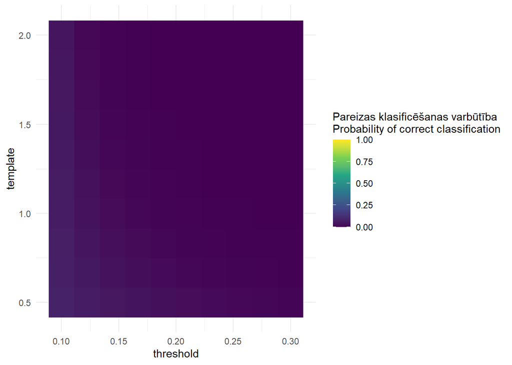

```r
# vizualizēšanai
th_seq = seq(min(visiDati2$threshold), max(visiDati2$threshold), length.out = 10)
temp_seq = seq(min(visiDati2$template), max(visiDati2$template), length.out = 10)

faktori = expand.grid(threshold = th_seq,
                   template = temp_seq)

faktori$prob = predict(model3, newdata = faktori, type = "response")

# heatmap
ggplot(faktori, aes(x = threshold, y = template, fill = prob)) +
  geom_raster()+
  scale_fill_viridis_c(
    name = "Pareizas klasificēšanas varbūtība\nProbability of correct classification",
    limits = c(0,1)
  )+
  theme_minimal() #šāda tipa grafikā šie dati nav labi pārskatāmi
```

#### Alternatīvi (līnijgrafiks)

```r
visiDati3 = visiDati %>% mutate (threshold = as.numeric(threshold))
unique(visiDati3$threshold) # pareizi, numeric
```

```
## [1] 0.1 0.2 0.3
```

```r
unique(visiDati3$template) # pareizi, kā kategorijas
```

```
## [1] "0.5 sec" "1.0 sec" "2.0 sec"
```

```r
model1_3 <- glm(
  validated_fragment ~ threshold,
  data = visiDati3,
  family = "binomial")

summary(model1_3) # AIC: 18169, th būtiski negatīvi ietekmē spēju pareizi klasificēt klātbūtni
```

```
##
## Call:
## glm(formula = validated_fragment ~ threshold, family = "binomial",
##     data = visiDati3)
##
## Coefficients:
##              Estimate Std. Error z value Pr(>|z|)
## (Intercept)  -1.02771    0.05908  -17.39   <2e-16 ***
## threshold   -16.83375    0.44691  -37.67   <2e-16 ***
## ---
## Signif. codes:  0 '***' 0.001 '**' 0.01 '*' 0.05 '.' 0.1 ' ' 1
##
## (Dispersion parameter for binomial family taken to be 1)
##
##     Null deviance: 20581  on 86399  degrees of freedom
## Residual deviance: 18165  on 86398  degrees of freedom
## AIC: 18169
##
## Number of Fisher Scoring iterations: 8
```

```r
pR2(model1_3) # modelis (threshold) pēc McFadden pseidodeterminācijas koeficienta izskaido 11.7% no spējas pareizi identificēt patiesu sugas klātbūtni
```

```
## fitting null model for pseudo-r2
```

```
##           llh       llhNull            G2      McFadden          r2ML
## -9.082586e+03 -1.029062e+04  2.416067e+03  1.173917e-01  2.757638e-02
##          r2CU
##  1.301007e-01
```

```r
model2_3 <- glm(
  validated_fragment ~ template,
  data = visiDati3,
  family = "binomial")

summary(model2_3) # AIC: 19807 - lielāka, bet template garums (kā kategorija) ietekmē spēju pareizi atrast klātbūtni būtiski negatīvi, proti - ar īsāku paraugu PM_MATCH strādā labāk. Jāpadomā kā interpretēt, bet šis varētu būt specifiski taisnspārņiem. Te var arī pārbaudīt kā ir ar pašu PM_MATCH (kas ietver gan true pos, gan false pos).
```

```
##
## Call:
## glm(formula = validated_fragment ~ template, family = "binomial",
##     data = visiDati3)
##
## Coefficients:
##                 Estimate Std. Error z value Pr(>|z|)
## (Intercept)     -3.01382    0.02790 -108.03   <2e-16 ***
## template1.0 sec -1.46852    0.06260  -23.46   <2e-16 ***
## template2.0 sec -0.94005    0.05156  -18.23   <2e-16 ***
## ---
## Signif. codes:  0 '***' 0.001 '**' 0.01 '*' 0.05 '.' 0.1 ' ' 1
##
## (Dispersion parameter for binomial family taken to be 1)
##
##     Null deviance: 20581  on 86399  degrees of freedom
## Residual deviance: 19801  on 86397  degrees of freedom
## AIC: 19807
##
## Number of Fisher Scoring iterations: 7
```

```r
pR2(model2_3) # parauga garums izskaidro tikai 3,7% no spējas pareizi identificēt patiesu sugas klātbūtni
```

```
## fitting null model for pseudo-r2
```

```
##           llh       llhNull            G2      McFadden          r2ML
## -9.900479e+03 -1.029062e+04  7.802829e+02  3.791234e-02  8.990395e-03
##          r2CU
##  4.241515e-02
```

```r
model3_3 <- glm(
  validated_fragment ~ threshold*template,
  data = visiDati3, # lai pārvērstu par kategorijām, nomaina te uz visiDati
  family = "binomial")

summary(model3_3) # AIC: 17134 (līdz šim labākais modelis), un arī visi būtiski, bet katrs par sevi
```

```
##
## Call:
## glm(formula = validated_fragment ~ threshold * template, family = "binomial",
##     data = visiDati3)
##
## Coefficients:
##                            Estimate Std. Error z value Pr(>|z|)
## (Intercept)                -0.86593    0.07044 -12.294  < 2e-16 ***
## threshold                 -13.06705    0.47667 -27.413  < 2e-16 ***
## template1.0 sec             0.06972    0.22993   0.303    0.762
## template2.0 sec             1.91093    0.30473   6.271 3.59e-10 ***
## threshold:template1.0 sec -13.36039    2.01537  -6.629 3.37e-11 ***
## threshold:template2.0 sec -25.77673    2.90411  -8.876  < 2e-16 ***
## ---
## Signif. codes:  0 '***' 0.001 '**' 0.01 '*' 0.05 '.' 0.1 ' ' 1
##
## (Dispersion parameter for binomial family taken to be 1)
##
##     Null deviance: 20581  on 86399  degrees of freedom
## Residual deviance: 17122  on 86394  degrees of freedom
## AIC: 17134
##
## Number of Fisher Scoring iterations: 10
```

```r
pR2(model3_3) # 16,8% izskaidrotā variācija
```

```
## fitting null model for pseudo-r2
```

```
##           llh       llhNull            G2      McFadden          r2ML
## -8.561037e+03 -1.029062e+04  3.459166e+03  1.680737e-01  3.924576e-02
##          r2CU
##  1.851548e-01
```

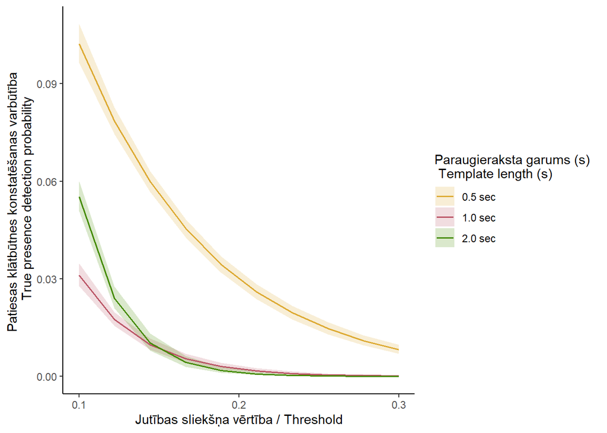

```r
# vizualizēšanai lai grafiks būtu smooth (gludāks nevis lausta līnija)
th_seq3 = seq(min(visiDati3$threshold), max(visiDati3$threshold), length.out = 10)

faktori3 = expand.grid(template=c("0.5 sec","1.0 sec","2.0 sec"),threshold=th_seq3)

prognoze3= predict(model3_3, newdata = faktori3, type = "link", se.fit = TRUE)

#aprēķinu CI
z <- qnorm(0.975) # CI kritiskā vērtība

faktori3$pred = prognoze3$fit
faktori3$pred_SE = prognoze3$se.fit

faktori3$prob    <- plogis(prognoze3$fit)
faktori3$SE      <- prognoze3$se.fit * faktori3$prob * (1 - faktori3$prob)
faktori3$lower   <- plogis(prognoze3$fit -z*prognoze3$se.fit)
faktori3$upper   <- plogis(prognoze3$fit +z*prognoze3$se.fit)

#GRAFIKS ar template + threshold ietekmi uz pareizu detektēšanu
ggplot(faktori3, aes(threshold, prob, colour = template)) +

  # pelēkais "mākonis" (bez rāmja)
  geom_ribbon(
    aes(ymin = lower, ymax = upper, fill = template),
    alpha = 0.2,
    colour = NA   # <- noņemu rāmīti
    ) +

  # līnija pa vidu (biezums)
  geom_line(linewidth = 0.7) +

  scale_x_continuous(
    breaks = c(0.1, 0.2, 0.3),
    labels = c("0.1", "0.2", "0.3")) +

  # krāsas
  scale_color_manual(values = c(
    "0.5 sec" = "#DDAA33",
    "1.0 sec" = "#BB5566",
    "2.0 sec" = "#458B00")) +

  scale_fill_manual(values = c(
    "0.5 sec" = "#DDAA33",
    "1.0 sec" = "#BB5566",
    "2.0 sec" = "#458B00")) +

  theme_classic() +

  labs(
    x = "Jutības sliekšņa vērtība / Threshold",
    y = "Patiesas klātbūtnes konstatēšanas varbūtība \n True presence detection probability",
    color = "Paraugieraksta garums (s) \n Template length (s)",
    fill  = "Paraugieraksta garums (s) \n Template length (s)")
```

```r
# 9 kombinācijas (3x3)
faktori4 = expand.grid(
  template = c("0.5 sec","1.0 sec","2.0 sec"),
  threshold = c(0.1, 0.2, 0.3))

# prognozes
prognoze4 = predict(model3_3, newdata = faktori4, type = "link", se.fit = TRUE)

# CI aprēķins
z <- qnorm(0.975)

faktori4$pred     <- prognoze4$fit
faktori4$pred_SE  <- prognoze4$se.fit

faktori4$prob  <- plogis(prognoze4$fit)
faktori4$lower <- plogis(prognoze4$fit - z * prognoze4$se.fit)
faktori4$upper <- plogis(prognoze4$fit + z * prognoze4$se.fit)

# rezultāts
faktori4 %>%
  arrange(template, threshold)
```

```
##   template threshold       pred    pred_SE         prob        lower
## 1  0.5 sec       0.1  -2.172638 0.03300351 1.022346e-01 9.644850e-02
## 2  0.5 sec       0.2  -3.479343 0.04196582 2.990573e-02 2.760958e-02
## 3  0.5 sec       0.3  -4.786048 0.08352989 8.276303e-03 7.035237e-03
## 4  1.0 sec       0.1  -3.438952 0.05867264 3.110004e-02 2.781560e-02
## 5  1.0 sec       0.2  -6.081696 0.18885953 2.279092e-03 1.575109e-03
## 6  1.0 sec       0.3  -8.724441 0.38024139 1.625373e-04 7.714860e-05
## 7  2.0 sec       0.1  -2.839377 0.04466914 5.523305e-02 5.083842e-02
## 8  2.0 sec       0.2  -6.723755 0.28323689 1.200573e-03 6.894758e-04
## 9  2.0 sec       0.3 -10.608133 0.56796465 2.471357e-05 8.118772e-06
##          upper
## 1 1.083263e-01
## 2 3.238648e-02
## 3 9.734155e-03
## 4 3.475844e-02
## 5 3.296676e-03
## 6 3.424025e-04
## 7 5.998355e-02
## 8 2.089746e-03
## 9 7.522565e-05
```

**Refleksija par GLM rezultātiem:**

**Modeļa konverģence un stabilitāte**  
Visi trīs GLM modeļi veiksmīgi konverģē bez brīdinājumiem, un standartkļūdas ir salīdzinoši nelielas. Tas norāda, ka parametru novērtējumi ir stabili un dati ir pietiekami informatīvi, lai ticami novērtētu gan `threshold`, gan `template`, gan to mijiedarbību.

**Modeļu salīdzinājums (deviance, AIC, skaidrotspēja)**  
Salīdzinot modeļus, redzams skaidrs uzlabojums, pievienojot papildus faktorus:

- Modelis ar **threshold**:
  - AIC = 18169
  - McFadden R² ≈ 0.117  
    Sliekšņa vērtība viena pati jau būtiski ietekmē detektēšanas varbūtību.
- Modelis ar **template**:
  - AIC = 19807
  - McFadden R² ≈ 0.038  
    Parauga garums viens pats izskaidro mazāku variācijas daļu.
- **Kombinētais modelis (threshold × template)**:
  - AIC = 17134 (zemākais → labākais modelis)
  - McFadden R² ≈ 0.168 (~16.8%)
  - Residual deviance samazinās no 20581 līdz 17122

Tas skaidri parāda, ka abu faktoru kombinācija būtiski uzlabo modeļa kvalitāti, un īpaši svarīga ir **mijiedarbība (interaction)** starp `threshold` un `template`.

**Ko nozīmē koeficienti (interpretācija)**

  **interaction termini ir ļoti būtiski un negatīvi**, kas nozīmē:  
  pie lielākiem sliekšņiem garāki template kļūst daudz neefektīvāki.

**9 kombināciju interpretācija:**

Tālāk redzamas prognozētās varbūtības (`prob`) katrai kombinācijai:

Template: 0.5 sec

- **0.1** ~0.102 (10.2%)
- **0.2** ~0.030 (3.0%)
- **0.3** ~0.008 (0.8%)

Īsākais fragments dod **visaugstāko detekcijas varbūtību visos sliekšņos**.  
Tomēr arī šeit redzams straujš kritums, palielinot threshold.

Template: 1.0 sec

- **0.1** ~0.031 (3.1%)
- **0.2** ~0.0023 (0.23%)
- **0.3** ~0.00016 (0.016%)

Jau pie 0.1 sliekšņa varbūtība ir ~3× mazāka nekā 0.5 sec gadījumā.  
Pie lielākiem sliekšņiem detekcija praktiski pazūd.

Template: 2.0 sec

- **0.1** ~0.055 (5.5%)
- **0.2** ~0.0012 (0.12%)
- **0.3** ~0.000025 (0.0025%)

Interesanti:

- pie **zemākā sliekšņa (0.1)** šis variants ir labāks nekā 1.0 sec
- bet pie augstākiem sliekšņiem tas kļūst **visneefektīvākais**

Galvenā likumsakarība

Interpretācija praktiskā nozīmē

- Augstāks slieksnis padara algoritmu konservatīvāku → mazāk false positives, bet arī **strauji samazinās true positives**
- Garāki fragmenti (1.0–2.0 sec) iespējams:
  - satur vairāk trokšņa vai variācijas
  - un pie stingrākiem sliekšņiem tos grūtāk atpazīt

SECINĀJUMS:

Uzdevuma mērķis bija novērtēt audio parauga garuma (`template`) un detektēšanas sliekšņa (`threshold`) ietekmi uz patiesas klātbūtnes konstatēšanas varbūtību (`validated_fragment`).

Rezultāti skaidri parāda, ka:

- **threshold ir visspēcīgākais faktors**, kas negatīvi ietekmē detekcijas varbūtību
- **template efekts nav vienkāršs**, bet būtiski mijiedarbojas ar threshold
- kombinētais modelis (GLM ar interaction) vislabāk apraksta datus (AIC = 17134, R² ≈ 16.8%)

Praktiski tas nozīmē:  
**optimālai detekcijai jāizvēlas zemāks slieksnis un īsāks audio fragments**, jo īpaši gadījumos, kad svarīgi maksimāli palielināt patiesas klātbūtnes noteikšanu.

Proporciju analīze parāda, ka **detektēšanas varbūtība (proportion of correct detections)** būtiski samazinās, palielinoties threshold vērtībai. Tas nozīmē, ka algoritms kļūst **konservatīvāks (retāk pieņem, ka suga ir klātesoša)**.

Vienlaikus novērojams, ka **parauga garums (template)** ietekmē rezultātus – garāki paraugi parasti uzrāda zemāku detektēšanas varbūtību, kas var būt saistīts ar sarežģītāku signāla struktūru.

## Citi vizuāli attēloti rezultāti

### Kā diennakts laiks ietekmē identificēšanu ar PM un Audiovizuāli

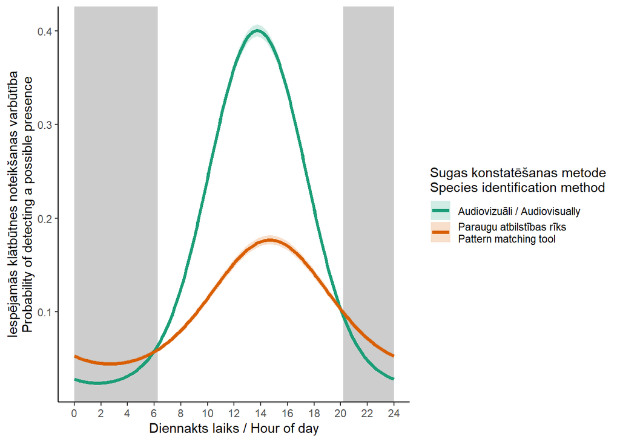

```r
# Datu sagatavošana
visiDati_long2 <- visiDati %>%

  select(DNstunda, MANUAL_MATCH, PM_MATCH) %>%

  pivot_longer(
    cols = c(MANUAL_MATCH, PM_MATCH),
    names_to = "method",
    values_to = "detection")

model_time2 <- glm(
  detection ~ method +
    sin(2*pi*DNstunda/24) +
    cos(2*pi*DNstunda/24) +
    method:sin(2*pi*DNstunda/24) +
    method:cos(2*pi*DNstunda/24),
  data = visiDati_long2,
  family = "binomial")

time_seq2 <- expand.grid(
  DNstunda = seq(0, 24, by = 0.1),
  method = c("MANUAL_MATCH", "PM_MATCH"))

pred2 <- predict(
  model_time2,
  newdata = time_seq2,
  type = "link",
  se.fit = TRUE)

time_seq2 <- time_seq2 %>%
  mutate(
    fit = pred2$fit,
    se  = pred2$se.fit,
    pred = plogis(fit),
    lower = plogis(fit - 1.96 * se),
    upper = plogis(fit + 1.96 * se))

# Grafiks

ggplot(time_seq2, aes(x = DNstunda, y = pred, color = method, fill = method)) +

  geom_rect(xmin = 20.18, xmax = 24, ymin = -Inf, ymax = Inf,
            fill = "grey80", alpha = 0.4, inherit.aes = FALSE) +

  geom_rect(xmin = 0, xmax = 6.29, ymin = -Inf, ymax = Inf,
            fill = "grey80", alpha = 0.4, inherit.aes = FALSE) +

  geom_ribbon(aes(ymin = lower, ymax = upper),
              alpha = 0.2, color = NA) +

  geom_line(linewidth = 1.3) +

  scale_x_continuous(
    breaks = seq(0, 24, 2),
    limits = c(0, 24)) +

  scale_color_manual(
    values = c(
      "MANUAL_MATCH" = "#1B9E77",
      "PM_MATCH" = "#D95F02"),
    labels = c(
      "MANUAL_MATCH" = "Audiovizuāli / Audiovisually",
      "PM_MATCH" = "Paraugu atbilstības rīks\nPattern matching tool")) +

  scale_fill_manual(
    values = c(
      "MANUAL_MATCH" = "#1B9E77",
      "PM_MATCH" = "#D95F02"),
    labels = c(
      "MANUAL_MATCH" = "Audiovizuāli / Audiovisually",
      "PM_MATCH" = "Paraugu atbilstības rīks\nPattern matching tool")) +

  theme_classic() +

  labs(
    x = "Diennakts laiks / Hour of day",
    y = "Iespējamās klātbūtnes noteikšanas varbūtība\nProbability of detecting a possible presence",
    color = "Sugas konstatēšanas metode\nSpecies identification method",
    fill  = "Sugas konstatēšanas metode\nSpecies identification method")
```

### Diennakts aktivitātes grafiks

Ja grib analizēt sugas klātbūtni, tad ir MANUAL jāizmanto par atbildes mainīgo!

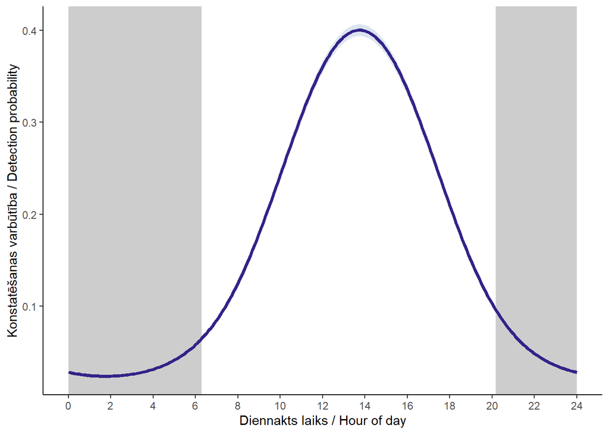

```r
# Modelis
model_time <- glm(
  MANUAL_MATCH ~ sin(2*pi*DNstunda/24) + cos(2*pi*DNstunda/24),
  data = visiDati,
  family = "binomial")

# Dati
time_seq <- data.frame(
  DNstunda = seq(0, 24, by = 0.1))

pred <- predict(
  model_time,
  newdata = time_seq,
  type = "link",
  se.fit = TRUE)

time_seq <- time_seq %>%
  mutate(
    fit = pred$fit,
    se  = pred$se.fit,
    pred = plogis(fit),
    lower = plogis(fit - 1.96 * se),
    upper = plogis(fit + 1.96 * se))

# GRAFIKS
ggplot(time_seq, aes(x = DNstunda, y = pred)) +

  # nakts zonas
  geom_rect(
    xmin = 20.18, xmax = 24,
    ymin = -Inf, ymax = Inf,
    fill = "grey80", alpha = 0.4) +

  geom_rect(
    xmin = 0, xmax = 6.29,
    ymin = -Inf, ymax = Inf,
    fill = "grey80", alpha = 0.4) +

  # uzticamības intervāls
  geom_ribbon(
    aes(ymin = lower, ymax = upper),
    fill = "#A6BDD7", alpha = 0.4) +

  # līkne
  geom_line(linewidth = 1.3, color = "#332288") +

  theme_classic() +

  scale_x_continuous(
    breaks = seq(0, 24, 2),
    limits = c(0, 24)) +

  labs(
    x = "Diennakts laiks / Hour of day",
    y = "Konstatēšanas varbūtība / Detection probability")
```

Mans viedoklis: Nu šis vienkārši labs standara informācijai par sugas aktivitāti diennaktī. Neko pielikt ne atņmet :) Ja kas tur ir arī “kļūdu mākonis” gar to līniju, bet viņš ir tik maziņš, ka neredz, bet viņš tur ir. Turklāt dienas un nakts iestāšanās laiks tika rēķināts pēc vidējās pētījuma dienās saules norietēšanas un uzlekšanas laika - šim ir pievērsta rūpīga uzmanība!

Saullēkta/saulrieta sīkāks paskaidrojums:

### Procenti pa biotopiem

“Pattern matching precizitāte (%) pa vietām”

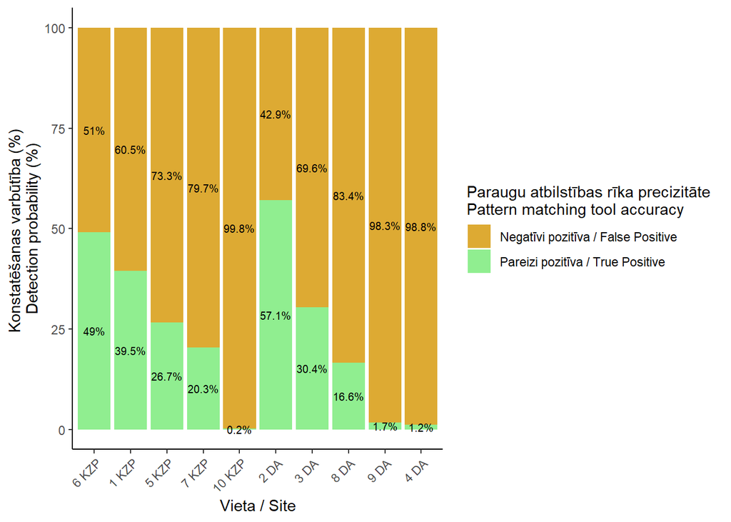

```r
# Sagatavo datus
site_summary <- visiDati %>%
  # pārsauc site
  mutate(site_name = paste0(
    str_extract(site_name, "^[0-9]+"), " ",
    ifelse(str_detect(site_name, "KZP"), "KZP", "DA")
  )) %>%
  filter(PM_MATCH == 1) %>%
  mutate(type = ifelse(validated_fragment == 1,
                       "Pareizi pozitīva / True Positive",
                       "Negatīvi pozitīva / False Positive")) %>%
  group_by(site_name, type) %>%
  summarise(count = n(), .groups = "drop")

# Procenti
pm_summary <- site_summary %>%
  group_by(site_name) %>%
  mutate(percent = count / sum(count) * 100) %>%
  ungroup()


# Datu kārtošanas loģika
# Izveidojam palīgtabulu, kas aprēķina "Pareizo" procentus un grupu
site_order_data <- pm_summary %>%
  mutate(
    # Atlasām tikai pareizos procentus kārtošanai (ja nav, ieliekam 0)
    correct_percent = ifelse(str_detect(type, "Pareizi pozitīva"), percent, 0)
  ) %>%
  group_by(site_name) %>%
  summarise(
    correct_percent = sum(correct_percent),
    # Piešķiram KZP grupai 1, bet DA grupai 2, lai KZP vienmēr būtu pirmie
    group_order = ifelse(str_detect(first(site_name), "KZP"), 1, 2),
    .groups = "drop" ) %>%
  # Kārtojam sākumā pēc grupas (1=KZP, 2=DA), pēc tam dilstoši pēc pareizajiem %
  arrange(group_order, desc(correct_percent))

# Pārveidojam site_name par faktoru, izmantojot mūsu izveidoto secību
pm_summary <- pm_summary %>%
  mutate(site_name = factor(site_name, levels = site_order_data$site_name))

# Grafiks

ggplot(pm_summary, aes(x = site_name, y = percent, fill = type)) +

  geom_col(position = "stack") +

  geom_text(
    aes(label = paste0(round(percent, 1), "%")),
    position = position_stack(vjust = 0.5),
    size = 2.7 ) +

  scale_fill_manual(values = c(
    "Pareizi pozitīva / True Positive" = "#90EE90",
    "Negatīvi pozitīva / False Positive" = "#DDAA33")) +

  theme_classic() +

  labs(
    x = "Vieta / Site",
    y = "Konstatēšanas varbūtība (%) \nDetection probability (%)",
    fill = "Paraugu atbilstības rīka precizitāte \nPattern matching tool accuracy ")+

  theme(axis.text.x = element_text(angle = 45, hjust = 1))
```

Mans viedoklis: Laba ideja, labi parāda kļūdu un pareizo detekciju sakitu uz visu 10 audiomothu fona un pa biotopiem.

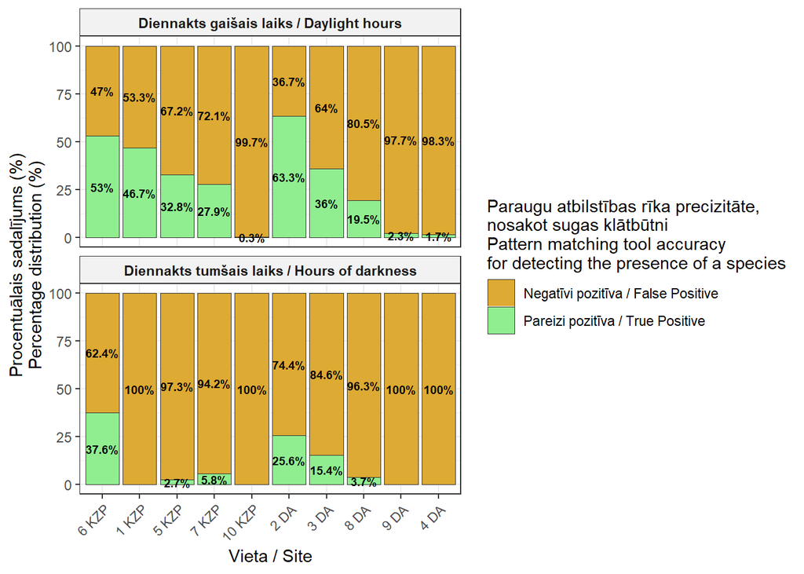

```r
# Datu sagatavošana ar laika filtrēšanu (izmantojot lubridate)
dati_ar_laiku <- visiDati %>%
  # Pārvēršam laiku par stundām (decimāldaļās), lai viegli salīdzinātu
  # Ja 'time' jau ir POSIXct (kā redzams tavā skriptā iepriekš), izmantojam hour() un minute()
  mutate(laiks_decimal = hour(time) + minute(time)/60 + second(time)/3600) %>%

  # Definējam robežas: 6:29 ir 6.4833, 20:18 ir 20.3
  mutate(period = ifelse(laiks_decimal >= (6 + 29/60) &
                         laiks_decimal < (20 + 18/60),
                         "Diennakts gaišais laiks / Daylight hours",
                         "Diennakts tumšais laiks / Hours of darkness")) %>%

  # Vietu nosaukumu sakārtošana (tava loģika)
  mutate(site_name = paste0(
    str_extract(site_name, "^[0-9]+"), " ",
    ifelse(str_detect(site_name, "KZP"), "KZP", "DA")
  )) %>%
  filter(PM_MATCH == 1) %>%
  mutate(type = ifelse(validated_fragment == 1,
                       "Pareizi pozitīva / True Positive",
                       "Negatīvi pozitīva / False Positive"))

# Aprēķinām procentus katram periodam un katrai vietai
summary_periodi <- dati_ar_laiku %>%
  group_by(period, site_name, type) %>%
  summarise(count = n(), .groups = "drop") %>%
  group_by(period, site_name) %>%
  mutate(percent = count / sum(count) * 100) %>%
  ungroup()

# Kārtošanas loģika (identiska tavai iepriekšējai, lai KZP būtu pirmie)
order_logic <- summary_periodi %>%
  filter(str_detect(type, "Pareizi")) %>%
  group_by(site_name) %>%
  summarise(
    max_correct = max(percent),
    group_order = ifelse(str_detect(first(site_name), "KZP"), 1, 2)
  ) %>%
  arrange(group_order, desc(max_correct))

summary_periodi <- summary_periodi %>%
  mutate(site_name = factor(site_name, levels = order_logic$site_name)) %>%
  # Pievienojam krāsu loģiku tekstam (balts uz tumši zila, melns uz oranža)
  mutate(label_color = ifelse(str_detect(type, "Pareizi"), "black", "black"))

# 4. GRAFIKS ar facet_wrap
ggplot(summary_periodi, aes(x = site_name, y = percent, fill = type)) +
  geom_col(position = "stack", color = "grey20", linewidth = 0.2) +

  # Sadalām divos grafikos (viens virs otra)
  facet_wrap(~period, ncol = 1) +

  geom_text(
    aes(label = paste0(round(percent, 1), "%"), color = label_color),
    position = position_stack(vjust = 0.5),
    size = 2.5,
    fontface = "bold"
  ) +

  # Izmantojam drošās krāsas (Zils/Oranžs), ko ieteicu iepriekš
  scale_fill_manual(values = c(
    "Pareizi pozitīva / True Positive" = "#90EE90",
    "Negatīvi pozitīva / False Positive" = "#DDAA33"
  )) +
  scale_color_manual(values = c("black" = "black", "black" = "black"), guide = "none") +

  theme_bw() +
  labs(
    x = "Vieta / Site",
    y = "Procentuālais sadalījums (%)\nPercentage distribution (%)",
    fill = "Paraugu atbilstības rīka precizitāte, \nnosakot sugas klātbūtni \nPattern matching tool accuracy \nfor detecting the presence of a species"
  ) +
  theme(
    axis.text.x = element_text(angle = 45, hjust = 1),
    strip.background = element_rect(fill = "grey95"),
    strip.text = element_text(face = "bold"))
```

## HIPOTĒZES SECINĀJUMS

1. Automātiskās klātbūtnes noteikšanas precizitāte ir atkarīga no izmantotā paraugieraksta garuma un uzstādītajiem parametriem.

2. Automātiskā sugas klātbūtnes konstatēšana bioakustiskajos datos ir iespējama, tomēr nav tik precīza, kā sugas konstatēšana pārbaudot ierakstus audiovizuāli.

## Beigas

```r
rm(list = ls())
```